# Titanic

```python
import pandas as pd
import numpy as np
import matplotlib as plt
import seaborn as sns
%matplotlib inline
import sklearn.model_selection as ms
from sklearn.linear_model import LogisticRegression
from sklearn.metrics import classification_report
logmodel = LogisticRegression()
```

```python
train = pd.read_csv('train.csv')
test = pd.read_csv('test.csv')
```

```python
train.head()
```

|  | PassengerId | Survived | Pclass | Name | Sex | Age | SibSp | Parch | Ticket | Fare | Cabin | Embarked |
| --- | --- | --- | --- | --- | --- | --- | --- | --- | --- | --- | --- | --- |
| 0 | 1 | 0 | 3 | Braund, Mr. Owen Harris | male | 22.0 | 1 | 0 | A/5 21171 | 7.2500 | NaN | S |
| 1 | 2 | 1 | 1 | Cumings, Mrs. John Bradley (Florence Briggs Th... | female | 38.0 | 1 | 0 | PC 17599 | 71.2833 | C85 | C |
| 2 | 3 | 1 | 3 | Heikkinen, Miss. Laina | female | 26.0 | 0 | 0 | STON/O2. 3101282 | 7.9250 | NaN | S |
| 3 | 4 | 1 | 1 | Futrelle, Mrs. Jacques Heath (Lily May Peel) | female | 35.0 | 1 | 0 | 113803 | 53.1000 | C123 | S |
| 4 | 5 | 0 | 3 | Allen, Mr. William Henry | male | 35.0 | 0 | 0 | 373450 | 8.0500 | NaN | S |

```python
test.head()
```

|  | PassengerId | Pclass | Name | Sex | Age | SibSp | Parch | Ticket | Fare | Cabin | Embarked |
| --- | --- | --- | --- | --- | --- | --- | --- | --- | --- | --- | --- |
| 0 | 892 | 3 | Kelly, Mr. James | male | 34.5 | 0 | 0 | 330911 | 7.8292 | NaN | Q |
| 1 | 893 | 3 | Wilkes, Mrs. James (Ellen Needs) | female | 47.0 | 1 | 0 | 363272 | 7.0000 | NaN | S |
| 2 | 894 | 2 | Myles, Mr. Thomas Francis | male | 62.0 | 0 | 0 | 240276 | 9.6875 | NaN | Q |
| 3 | 895 | 3 | Wirz, Mr. Albert | male | 27.0 | 0 | 0 | 315154 | 8.6625 | NaN | S |
| 4 | 896 | 3 | Hirvonen, Mrs. Alexander (Helga E Lindqvist) | female | 22.0 | 1 | 1 | 3101298 | 12.2875 | NaN | S |

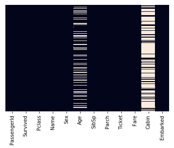

```python
sns.heatmap(data=train.isnull(), yticklabels=False, cbar=False)
```

```python
train.groupby('Pclass').mean()
```

| Pclass | PassengerId | Survived | Age | SibSp | Parch | Fare |
| --- | --- | --- | --- | --- | --- | --- |
| 1 | 461.597222 | 0.629630 | 38.233441 | 0.416667 | 0.356481 | 84.154687 |
| 2 | 445.956522 | 0.472826 | 29.877630 | 0.402174 | 0.380435 | 20.662183 |
| 3 | 439.154786 | 0.242363 | 25.140620 | 0.615071 | 0.393075 | 13.675550 |

```python
def fill_in_age(cols):
    age = cols[0]
    pclass = cols[1]
    if pd.isnull(age):
        if pclass==1:
            return 38.23
        elif pclass==2:
            return 29.88
        else:
            return 25.14
        return age
    else:
        return age
```

```python
train['Age'] = train[['Age','Pclass']].apply(fill_in_age,axis=1)
```

Filled in missing age values.

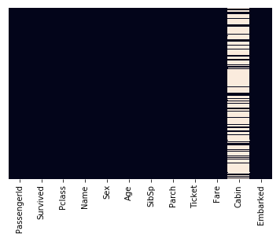

```python
sns.heatmap(data=train.isnull(), yticklabels=False, cbar=False)
```

I don't think we can do much with the cabin data. I will drop it.

```python
train.drop('Cabin',inplace=True, axis=1)
train.dropna(inplace=True)
```

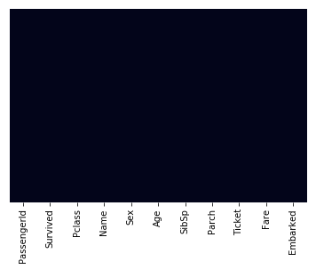

```python
sns.heatmap(data=train.isnull(), yticklabels=False, cbar=False)
```

```python
sns.set_style('darkgrid')
```

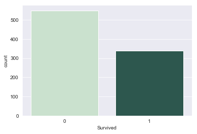

```python
sns.countplot(x='Survived',data=train, palette='ch:2.5,-.2,dark=.3')
```

But lets first see the number of people who died and survived.

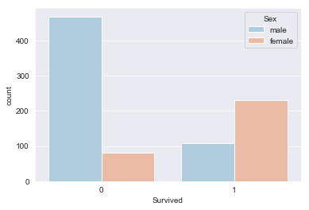

```python
sns.countplot(x='Survived', hue='Sex',data=train, palette='RdBu_r')
```

Number of people who survived and died based on gender.

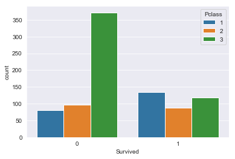

```python
sns.countplot(data=train, x='Survived', hue='Pclass')
```

Seems as if most the people who died were in third class, while the people who survived were a little more evenly distributed.

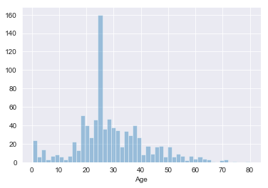

```python
sns.distplot(train['Age'].dropna(),kde=False, bins=50)
```

Age of all Titanic passengers is a bimodal distribution.

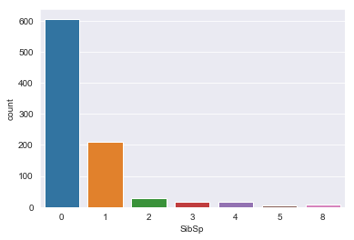

```python
sns.countplot(x='SibSp', data=train)
```

Most people did not have any spouses or siblings on board, which makes sense. Geometric distribution.

Lets adjust ticket Fare for inflation 1912 vs 2018. Rate = 2,507.06% // Source: https://data.bls.gov/cgi-bin/cpicalc.pl

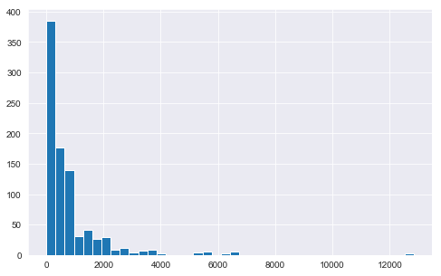

```python
train['Fare'] = train['Fare']*25.07
train['Fare'].hist(bins=40, figsize=(8,5))
```

```python
sex = pd.get_dummies(train['Sex'],drop_first=True)
```

```python
embark = pd.get_dummies(train['Embarked'],drop_first=True)
```

```python
pclass = pd.get_dummies(train['Pclass'])
```

```python
train = pd.concat([train,sex,embark,pclass],axis=1)
```

```python
train = train.drop(['Sex','Name','Embarked','Ticket','PassengerId'], axis=1)
```

```python
X = train.drop('Survived', axis = 1)
y = train['Survived']
```

```python
X_train, X_test, y_train, y_test = ms.train_test_split(X, y, test_size=.3, random_state=200)
```

```python
logmodel.fit(X_train, y_train)
```

```
LogisticRegression(C=1.0, class_weight=None, dual=False, fit_intercept=True,
          intercept_scaling=1, max_iter=100, multi_class='warn',
          n_jobs=None, penalty='l2', random_state=None, solver='warn',
          tol=0.0001, verbose=0, warm_start=False)
```

```python
predictions = logmodel.predict(X_test)
```

```python
print(classification_report(y_test,predictions))
```

```
              precision    recall  f1-score   support

           0       0.84      0.92      0.88       161
           1       0.86      0.73      0.79       106

   micro avg       0.84      0.84      0.84       267
   macro avg       0.85      0.82      0.83       267
weighted avg       0.84      0.84      0.84       267
```

Precision = TruePositives / TruePositives+FalsePositives  
Recall = TruePositives / TruePositives+FalseNegatives  
F1-Score = Harmonic mean of precision and recall  
Support = Number of occurences in each class  
Pretty accurate, f1-score is 88% for Not Survive and 79% for Survived